# Variable Selection Question 2

Mary Fisher

February 28, 2020

#### Research Question: Can we predict giant kelp size and abundance from oceanographic conditions and herbivore abundance (predictor)?

**Response variables:** Giant kelp mean abundance, max abundance; Giant kelp mean size, maximum size.

**Predictor variables:**

1. Urchin abundance: Sea urchins are herbivores, and in large numbers (also called “herds”) can decimate kelp forests. We have three measures of urchin abundance - red urchin abundance, purple urchin abundance, and urchin abundance across all species.
2. Water chemistry: Like any algae / plant, kelp requires nutrients to grow. We have measurements for the following nutrients: nitrogen, ammonia, urea, and phosphorus. We also have chlorophyl concentrations, which is a general index of primary productivity.
3. Water temperature: All species have a thermal range, or a range of temperatures, at which they grow best; the degree of variability in temperature can also have an impact on growth. With kelp forest loss from recent marine heatwaves and long-term warming, there has been much interest in whether kelp are impacted by an absolute temperature threshold, or by the degree of variability in temperature. We have mean summer and mean winter temperatures, and variation in summer and mean winter temperatures.
4. Giant kelp mean / max abundance, mean / max size at t-1: This data set is a time series, so the giant kelp response variable at a given site for year `t` should be dependent on giant kelp condition in year `t-1`.

Read in data

```r
mydat <- read.csv(here::here("data","kelp_prediction_data_complete.csv")) %>%
  clean_names()
head(mydat)
```

```
##   year month site transect mapy_mean_abund mapy_max_abund mapy_mean_size
## 1 2002     8 CARP        1       0.6245833            0.8       15.48148
## 2 2002     8 CARP        2       0.0000000            0.0             NA
## 3 2002     8 CARP        3       0.0000000            0.0             NA
## 4 2002     8 CARP        4       0.0000000            0.0             NA
## 5 2002     8 CARP        5       0.0000000            0.0             NA
## 6 2002     8 CARP        6       0.0000000            0.0             NA
##   mapy_max_size franciscanus_abundance purpuratus_abundance urchin_abundance
## 1            30                      9                   92              101
## 2            NA                      2                  144              146
## 3            NA                      6                  138              144
## 4            NA                      2                  431              433
## 5            NA                      5                  312              317
## 6            NA                      9                  334              343
##   max_ammonia max_no2_no3 max_po4  max_poc max_pon max_tchl mean_ammonia
```

[output cut: 20 more lines]

Add in the giant kelp response variables for `t-1`.

```r
# need kelp info from 2001
kelp_dat <- read.csv(here::here("data","Annual_Kelp_MeanSize_MeanAbund_2001-2018.csv")) %>%
  clean_names() %>%
  filter(site %in% mydat$site & year == 2001) %>%
  dplyr::select(-scientific_name,-group, -month) %>%
  rename("prev_mean_abund" = mapy_mean_abund,"prev_max_abund"=mapy_max_abund,
         "prev_mean_size"=mapy_mean_size,"prev_max_size"=mapy_max_size) %>%
  mutate(year = year + 1)
kelp_prev <- read.csv(here::here("data","kelp_prediction_data.csv")) %>%
  clean_names() %>%
  dplyr::select(year,month,site,transect,
                                     mapy_mean_abund,mapy_max_abund,mapy_mean_size,mapy_max_size) %>%
  rename("prev_mean_abund" = mapy_mean_abund,"prev_max_abund"=mapy_max_abund,
         "prev_mean_size"=mapy_mean_size,"prev_max_size"=mapy_max_size) %>%
  mutate(year = year + 1) %>%
  dplyr::select(-month) %>%
  rbind(kelp_dat)
mydat <- left_join(mydat,kelp_prev,by=c("year","site","transect"))
message("\nThere are ", sum(is.na(mydat$prev_mean_abund)), " missing measurements for the previous year's kelp abundance.\n")
```

```
##
## There are 0 missing measurements for the previous year's kelp abundance.
```

```r
head(mydat %>% dplyr::select(year,site,transect,mapy_mean_abund,prev_mean_abund,prev_max_abund,prev_mean_size,prev_max_size))
```

```
##   year site transect mapy_mean_abund prev_mean_abund prev_max_abund
## 1 2002 CARP        1       0.6245833       0.3130952      0.5333333
## 2 2002 CARP        2       0.0000000       0.0000000      0.0000000
## 3 2002 CARP        3       0.0000000       0.0000000      0.0000000
## 4 2002 CARP        4       0.0000000       0.0000000      0.0000000
## 5 2002 CARP        5       0.0000000       0.0000000      0.0000000
## 6 2002 CARP        6       0.0000000       0.0000000      0.0000000
##   prev_mean_size prev_max_size
## 1          18.25            29
## 2             NA            NA
## 3             NA            NA
## 4             NA            NA
## 5             NA            NA
## 6             NA            NA
```

## Multicolinearity / Predictor Selection

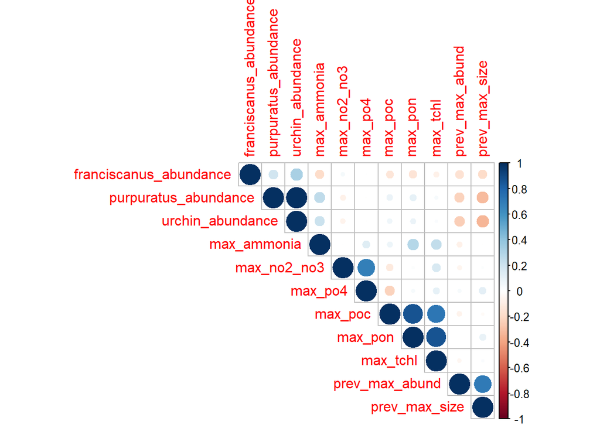

```r
corrplot(cor(mydat[,c(9:17,29,31)],use="complete.obs"), type="upper")
```

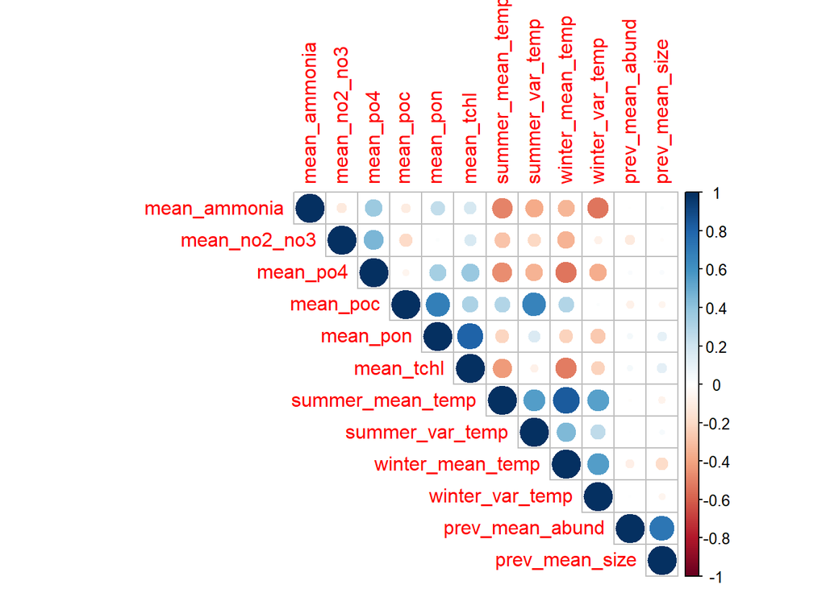

```r
corrplot(cor(mydat[,c(18:28,30)], use="complete.obs"), type="upper")
```

We have three variables that quantify urchin abundance - we’ll just work with total abundance (`urchin_abundance`).

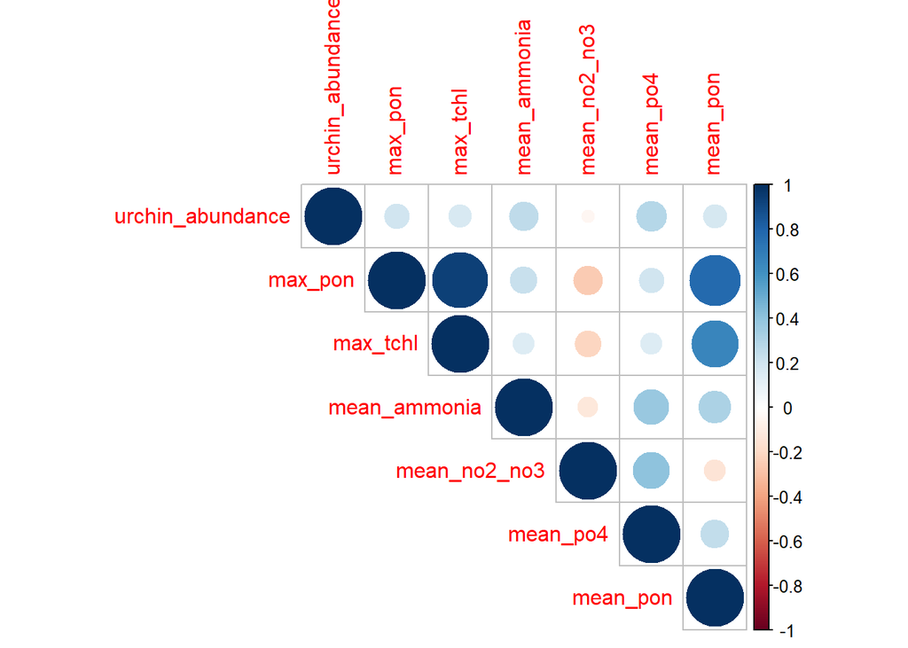

```r
lmdat <- mydat %>%
  dplyr::select(-purpuratus_abundance,-franciscanus_abundance,-summer_var_temp,-winter_var_temp)
corrplot(cor(lmdat[,c(9,14:18,20)],use="complete.obs"),type="upper")
```

## Model Selection & Diagnostics

### Size of Giant Kelp

#### Fit model

```r
n <- dim(lmdat)[1]
fit.a <- lm(mapy_mean_size ~ urchin_abundance+site+
              mean_no2_no3+mean_ammonia+mean_tchl+mean_pon+mean_poc+
              summer_mean_temp+winter_mean_temp+
              prev_mean_size+site*prev_mean_size,data=lmdat)
scp <- list(lower = ~ 1,
           upper = ~ urchin_abundance+site+
              mean_no2_no3+mean_ammonia+mean_tchl+mean_pon+mean_poc+
             summer_mean_temp+winter_mean_temp+
              prev_mean_size+site*prev_mean_size)

fit.f <- step(fit.a, scope = scp, direction = "backward",  k = log(n))
```

```
## Start:  AIC=1365.51
## mapy_mean_size ~ urchin_abundance + site + mean_no2_no3 + mean_ammonia +
##     mean_tchl + mean_pon + mean_poc + summer_mean_temp + winter_mean_temp +
##     prev_mean_size + site * prev_mean_size
##
##                       Df Sum of Sq   RSS    AIC
## - site:prev_mean_size  4    814.64 60619 1345.3
## - mean_no2_no3         1     36.52 59840 1359.8
## - mean_pon             1     70.93 59875 1360.0
## - mean_poc             1    133.91 59938 1360.2
## - mean_tchl            1    383.70 60188 1361.1
## - winter_mean_temp     1   1373.65 61178 1364.8
## - urchin_abundance     1   1422.31 61226 1365.0
## - mean_ammonia         1   1545.32 61349 1365.5
## <none>                             59804 1365.5
## - summer_mean_temp     1   2185.66 61990 1367.8
##
## Step:  AIC=1345.27
## mapy_mean_size ~ urchin_abundance + site + mean_no2_no3 + mean_ammonia +
##     mean_tchl + mean_pon + mean_poc + summer_mean_temp + winter_mean_temp +
##     prev_mean_size
##
##                    Df Sum of Sq   RSS    AIC
## - mean_no2_no3      1       8.7 60627 1339.5
## - mean_pon          1      98.3 60717 1339.8
## - mean_poc          1     106.6 60725 1339.8
## - mean_tchl         1     463.2 61082 1341.2
## - winter_mean_temp  1    1362.5 61981 1344.5
## - urchin_abundance  1    1398.2 62017 1344.6
## <none>                          60619 1345.3
## - mean_ammonia      1    1610.2 62229 1345.4
## - summer_mean_temp  1    2182.9 62801 1347.5
## - prev_mean_size    1    4982.0 65601 1357.3
## - site              4   10381.4 71000 1357.7
##
## Step:  AIC=1339.48
## mapy_mean_size ~ urchin_abundance + site + mean_ammonia + mean_tchl +
##     mean_pon + mean_poc + summer_mean_temp + winter_mean_temp +
##     prev_mean_size
##
```

[output cut: 69 more lines]

```
##                    Df Sum of Sq   RSS    AIC
## - mean_ammonia      1    1100.7 65159 1320.8
## <none>                          64058 1322.8
## - urchin_abundance  1    2582.0 66640 1325.9
## - prev_mean_size    1    6539.9 70598 1339.0
## - site              4   12815.6 76874 1340.7
##
## Step:  AIC=1320.84
## mapy_mean_size ~ urchin_abundance + site + prev_mean_size
##
##                    Df Sum of Sq   RSS    AIC
## <none>                          65159 1320.8
## - urchin_abundance  1    2229.0 67388 1322.6
## - prev_mean_size    1    6870.4 72029 1337.7
## - site              4   13994.6 79153 1341.5
```

```r
n <- dim(lmdat)[1]
fit.e <- lm(mapy_mean_size ~ 1,data=lmdat)

fit.f <- step(fit.e, scope = scp, direction = "forward",  k = log(n))
```

```r
summary(fit.f)
```

```
##
## Call:
## lm(formula = mapy_mean_size ~ urchin_abundance + site + prev_mean_size,
##     data = lmdat)
##
## Residuals:
##     Min      1Q  Median      3Q     Max
## -46.353 -10.400  -1.330   8.404  70.825
##
## Coefficients:
##                  Estimate Std. Error t value Pr(>|t|)
## (Intercept)      24.58696    4.98905   4.928 1.64e-06 ***
## urchin_abundance -0.04807    0.01756  -2.737  0.00671 **
## siteAQUE         26.86216    5.69641   4.716 4.29e-06 ***
## siteCARP         -0.59219    5.56521  -0.106  0.91536
## siteMOHK         11.03111    5.76830   1.912  0.05713 .
## siteNAPL         -0.62712    4.89781  -0.128  0.89823
## prev_mean_size    0.30071    0.06258   4.805 2.87e-06 ***
## ---
## Signif. codes:  0 '***' 0.001 '**' 0.01 '*' 0.05 '.' 0.1 ' ' 1
##
## Residual standard error: 17.25 on 219 degrees of freedom
##   (112 observations deleted due to missingness)
## Multiple R-squared:  0.4733, Adjusted R-squared:  0.4589
## F-statistic:  32.8 on 6 and 219 DF,  p-value: < 2.2e-16
```

How does RSE / R squared compare to full model

```r
summary(fit.a)
```

```
##
## Call:
## lm(formula = mapy_mean_size ~ urchin_abundance + site + mean_no2_no3 +
##     mean_ammonia + mean_tchl + mean_pon + mean_poc + summer_mean_temp +
##     winter_mean_temp + prev_mean_size + site * prev_mean_size,
##     data = lmdat)
##
## Residuals:
##     Min      1Q  Median      3Q     Max
## -51.222  -9.583  -1.688   8.774  68.930
##
## Coefficients:
##                          Estimate Std. Error t value Pr(>|t|)
## (Intercept)             -8.380307  44.448354  -0.189  0.85064
## urchin_abundance        -0.041034   0.018449  -2.224  0.02721 *
## siteAQUE                16.845492  11.115499   1.515  0.13117
## siteCARP                -6.682531  10.539488  -0.634  0.52675
## siteMOHK                 5.863702  13.858822   0.423  0.67266
## siteNAPL                 2.820040   9.888393   0.285  0.77578
## mean_no2_no3             0.003241   0.009094   0.356  0.72191
## mean_ammonia             0.015924   0.006869   2.318  0.02140 *
## mean_tchl               -2.049135   1.773805  -1.155  0.24933
## mean_pon                 1.186774   2.389311   0.497  0.61992
## mean_poc                 0.099434   0.145698   0.682  0.49571
## summer_mean_temp         6.926127   2.512071   2.757  0.00635 **
## winter_mean_temp        -6.438671   2.945721  -2.186  0.02995 *
## prev_mean_size           0.244042   0.196688   1.241  0.21609
## siteAQUE:prev_mean_size  0.126009   0.220196   0.572  0.56776
## siteCARP:prev_mean_size -0.034231   0.238622  -0.143  0.88607
## siteMOHK:prev_mean_size  0.026947   0.303813   0.089  0.92941
## siteNAPL:prev_mean_size -0.161456   0.247804  -0.652  0.51541
## ---
## Signif. codes:  0 '***' 0.001 '**' 0.01 '*' 0.05 '.' 0.1 ' ' 1
##
## Residual standard error: 16.96 on 208 degrees of freedom
##   (112 observations deleted due to missingness)
## Multiple R-squared:  0.5166, Adjusted R-squared:  0.4771
## F-statistic: 13.08 on 17 and 208 DF,  p-value: < 2.2e-16
```

#### Model Diagnostics

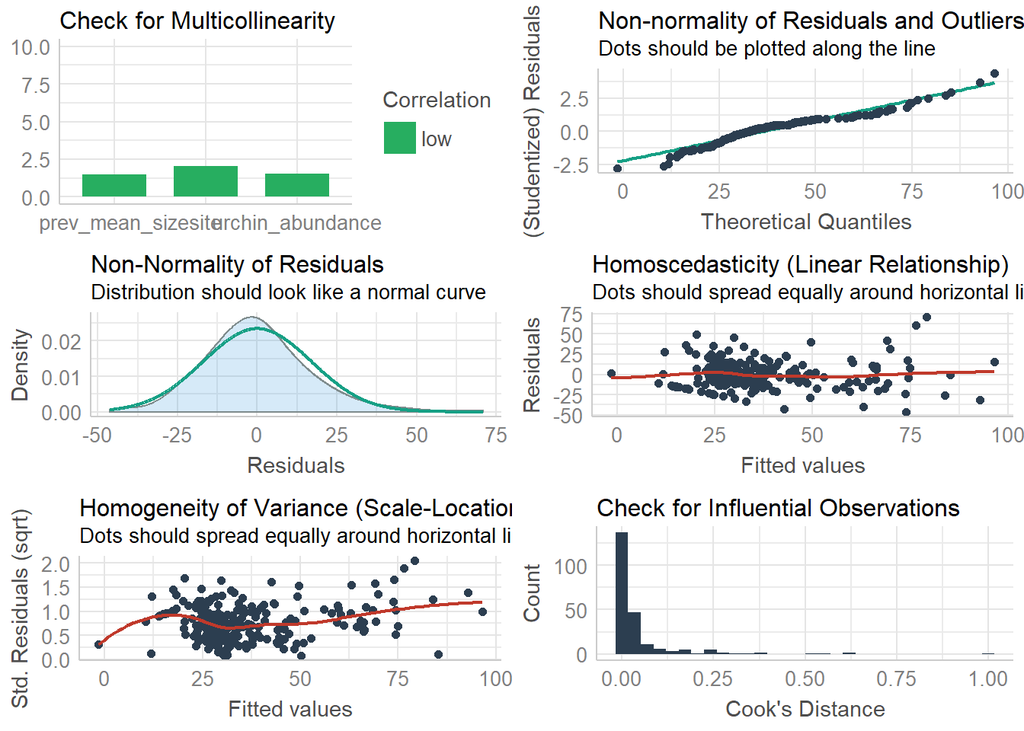

```r
check_model(fit.f)
```

### Abundance of Giant Kelp

#### Fit Model

```r
n <- dim(lmdat)[1]
fit.abund.e <- lm(mapy_mean_abund ~ 1,data=lmdat)
fit.abund.a <- lm(mapy_mean_abund ~  urchin_abundance+site+
              mean_no2_no3+mean_ammonia+mean_tchl+mean_pon+mean_poc+
              summer_mean_temp+winter_mean_temp+
              prev_mean_size+site*prev_mean_size,data=lmdat)
scp <- list(lower = ~ 1,
           upper = ~  urchin_abundance+site+
              mean_no2_no3+mean_ammonia+mean_tchl+mean_pon+mean_poc+
              summer_mean_temp+winter_mean_temp+
              prev_mean_size+site*prev_mean_size,data=lmdat)
```

```r
fit.abund.f <- step(fit.abund.e, scope = scp, direction = "forward",  k = log(n))
```

```r
fit.abund.f <- step(fit.abund.a, direction = "backward",  k = log(n))
```

```
## Start:  AIC=-163.38
## mapy_mean_abund ~ urchin_abundance + site + mean_no2_no3 + mean_ammonia +
##     mean_tchl + mean_pon + mean_poc + summer_mean_temp + winter_mean_temp +
##     prev_mean_size + site * prev_mean_size
##
##                       Df Sum of Sq     RSS     AIC
## - site:prev_mean_size  4    1.5161 100.035 -182.58
## - mean_poc             1    0.0400  98.559 -169.10
## - mean_pon             1    0.2952  98.814 -168.41
## - mean_tchl            1    0.3134  98.832 -168.36
## - mean_ammonia         1    0.7696  99.288 -167.12
## - summer_mean_temp     1    1.0147  99.533 -166.46
## - mean_no2_no3         1    1.5136 100.032 -165.12
## - winter_mean_temp     1    2.0297 100.548 -163.74
## <none>                              98.519 -163.38
## - urchin_abundance     1    3.2022 101.721 -160.63
##
## Step:  AIC=-182.58
## mapy_mean_abund ~ urchin_abundance + site + mean_no2_no3 + mean_ammonia +
##     mean_tchl + mean_pon + mean_poc + summer_mean_temp + winter_mean_temp +
##     prev_mean_size
##
##                    Df Sum of Sq    RSS     AIC
## - mean_poc          1    0.0442 100.08 -188.29
## - mean_pon          1    0.2141 100.25 -187.83
## - mean_tchl         1    0.2489 100.28 -187.74
## - mean_ammonia      1    0.7710 100.81 -186.35
## - summer_mean_temp  1    0.9346 100.97 -185.91
## - site              4    8.0703 108.11 -185.08
## - winter_mean_temp  1    1.5757 101.61 -184.22
## - prev_mean_size    1    1.6095 101.64 -184.13
## - mean_no2_no3      1    1.7013 101.74 -183.89
## <none>                          100.03 -182.58
## - urchin_abundance  1    2.3941 102.43 -182.07
##
## Step:  AIC=-188.29
## mapy_mean_abund ~ urchin_abundance + site + mean_no2_no3 + mean_ammonia +
##     mean_tchl + mean_pon + summer_mean_temp + winter_mean_temp +
##     prev_mean_size
##
```

[output cut: 61 more lines]

```
## <none>                          101.77 -207.09
## - prev_mean_size    1    2.5973 104.36 -206.16
## - mean_no2_no3      1    2.6769 104.44 -205.96
## - urchin_abundance  1    2.7865 104.55 -205.68
##
## Step:  AIC=-208.64
## mapy_mean_abund ~ urchin_abundance + mean_no2_no3 + winter_mean_temp +
##     prev_mean_size
##
##                    Df Sum of Sq    RSS     AIC
## <none>                          110.37 -208.64
## - winter_mean_temp  1    4.6972 115.07 -203.30
## - urchin_abundance  1    5.2658 115.63 -201.98
## - mean_no2_no3      1    8.5040 118.87 -194.57
## - prev_mean_size    1    9.9544 120.32 -191.32
```

```r
summary(fit.abund.f)
```

```
##
## Call:
## lm(formula = mapy_mean_abund ~ urchin_abundance + mean_no2_no3 +
##     winter_mean_temp + prev_mean_size, data = lmdat)
##
## Residuals:
##     Min      1Q  Median      3Q     Max
## -1.2225 -0.4012 -0.0916  0.2452  3.7501
##
## Coefficients:
##                    Estimate Std. Error t value Pr(>|t|)
## (Intercept)       3.7378662  0.8095324   4.617 6.09e-06 ***
## urchin_abundance -0.0017318  0.0004889  -3.542 0.000469 ***
## mean_no2_no3     -0.0012163  0.0002702  -4.502 1.01e-05 ***
## winter_mean_temp -0.1599238  0.0478013  -3.346 0.000941 ***
## prev_mean_size    0.0093197  0.0019135   4.870 1.93e-06 ***
## ---
## Signif. codes:  0 '***' 0.001 '**' 0.01 '*' 0.05 '.' 0.1 ' ' 1
##
## Residual standard error: 0.6478 on 263 degrees of freedom
##   (70 observations deleted due to missingness)
## Multiple R-squared:  0.2539, Adjusted R-squared:  0.2426
## F-statistic: 22.38 on 4 and 263 DF,  p-value: 6.408e-16
```

```r
summary(fit.abund.a)
```

```
##
## Call:
## lm(formula = mapy_mean_abund ~ urchin_abundance + site + mean_no2_no3 +
##     mean_ammonia + mean_tchl + mean_pon + mean_poc + summer_mean_temp +
##     winter_mean_temp + prev_mean_size + site * prev_mean_size,
##     data = lmdat)
##
## Residuals:
##     Min      1Q  Median      3Q     Max
## -1.1930 -0.3338 -0.0794  0.2323  3.9267
##
## Coefficients:
##                           Estimate Std. Error t value Pr(>|t|)
## (Intercept)              1.3721653  1.4586679   0.941  0.34777
## urchin_abundance        -0.0016503  0.0005789  -2.851  0.00473 **
## siteAQUE                 0.6624409  0.3710386   1.785  0.07541 .
## siteCARP                 0.2554784  0.3174966   0.805  0.42178
## siteMOHK                 0.3049138  0.4831041   0.631  0.52852
## siteNAPL                 0.0737515  0.3105517   0.237  0.81247
## mean_no2_no3            -0.0006085  0.0003105  -1.960  0.05113 .
## mean_ammonia             0.0003036  0.0002172   1.397  0.16350
## mean_tchl               -0.0500975  0.0561745  -0.892  0.37335
## mean_pon                 0.0676933  0.0782092   0.866  0.38757
## mean_poc                -0.0014396  0.0045186  -0.319  0.75030
## summer_mean_temp         0.1419431  0.0884593   1.605  0.10984
## winter_mean_temp        -0.2211736  0.0974552  -2.269  0.02409 *
## prev_mean_size           0.0099906  0.0065331   1.529  0.12747
## siteAQUE:prev_mean_size -0.0046312  0.0074709  -0.620  0.53589
## siteCARP:prev_mean_size -0.0118530  0.0076057  -1.558  0.12039
## siteMOHK:prev_mean_size  0.0006801  0.0107691   0.063  0.94970
## siteNAPL:prev_mean_size -0.0036085  0.0082082  -0.440  0.66060
## ---
## Signif. codes:  0 '***' 0.001 '**' 0.01 '*' 0.05 '.' 0.1 ' ' 1
##
## Residual standard error: 0.6278 on 250 degrees of freedom
##   (70 observations deleted due to missingness)
## Multiple R-squared:  0.334,  Adjusted R-squared:  0.2888
## F-statistic: 7.376 on 17 and 250 DF,  p-value: 1.264e-14
```

#### Model Diagnostics

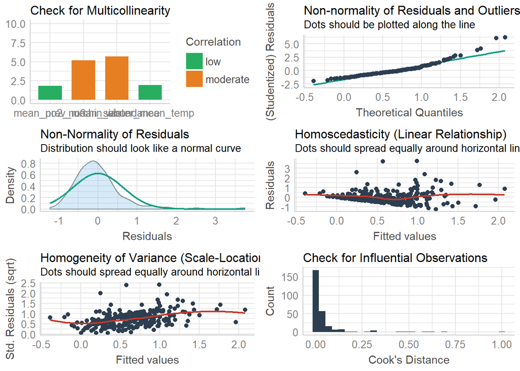

```r
check_model(fit.abund.f)
```